# Ch25_lab

Holden Jones

2023-01-31

# Many models

# 25.1 Introduction

# 25.2 gapminder

from Hans Rosling - Swedish doctor and statistician

`r library(gapminder) gapminder`

`` ## # A tibble: 1,704 x 6 ## country continent year lifeExp pop gdpPercap ## <fct> <fct> <int> <dbl> <int> <dbl> ## 1 Afghanistan Asia 1952 28.8 8425333 779. ## 2 Afghanistan Asia 1957 30.3 9240934 821. ## 3 Afghanistan Asia 1962 32.0 10267083 853. ## 4 Afghanistan Asia 1967 34.0 11537966 836. ## 5 Afghanistan Asia 1972 36.1 13079460 740. ## 6 Afghanistan Asia 1977 38.4 14880372 786. ## 7 Afghanistan Asia 1982 39.9 12881816 978. ## 8 Afghanistan Asia 1987 40.8 13867957 852. ## 9 Afghanistan Asia 1992 41.7 16317921 649. ## 10 Afghanistan Asia 1997 41.8 22227415 635. ## # … with 1,694 more rows ## # ℹ Use `print(n = ...)` to see more rows ``

focus on: how does lifeExp change over year for each country

`r gapminder %>% ggplot(aes(year, lifeExp, group = country)) + geom_line(alpha = 1/3)`

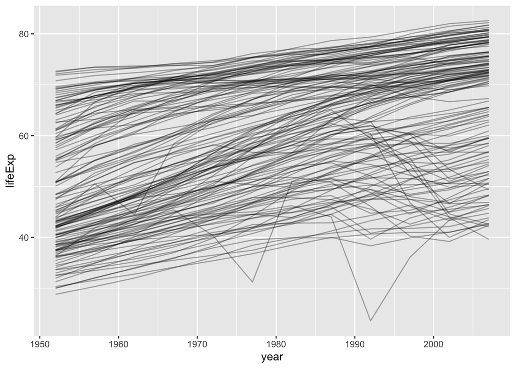

`r # see that generally life expectancy increases over time, but some exceptions!`

think like from last chapter - strong signal of overall linear growth makes hard to see subtler trends - model captures steady growth over time, and residuals will show what’s left

`r # know how to do this for one country nz <- filter(gapminder, country == "New Zealand") nz %>% ggplot(aes(year, lifeExp)) + geom_line() + ggtitle("Full data = ")`

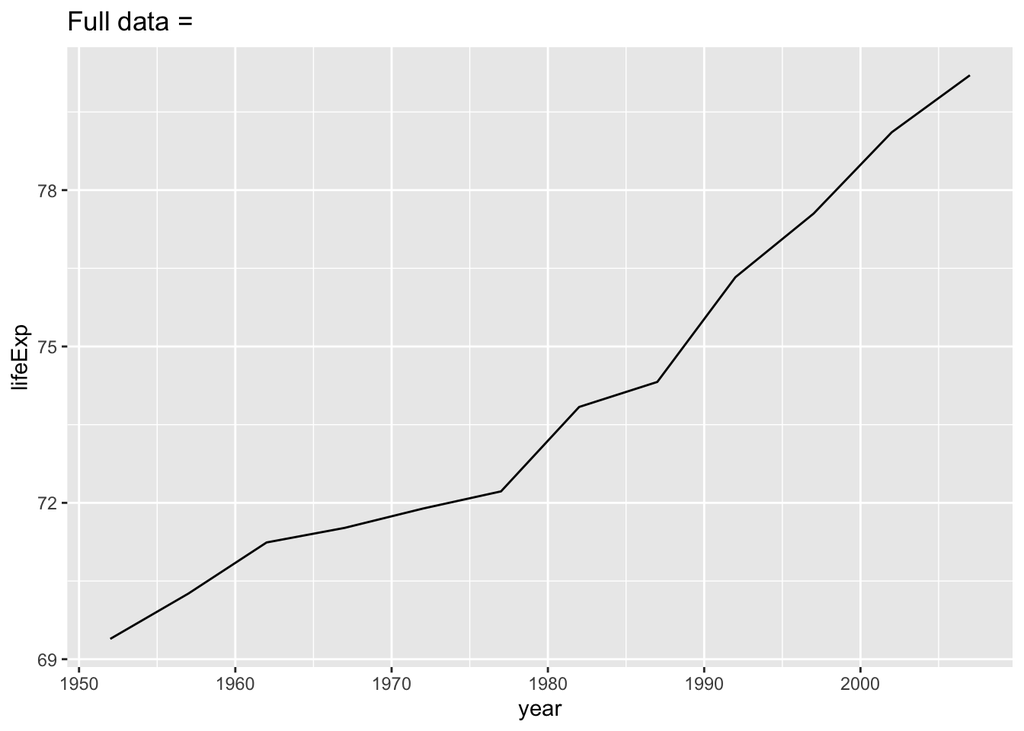

`r nz_mod <- lm(lifeExp ~ year, data = nz) nz %>% add_predictions(nz_mod) %>% ggplot(aes(year, pred)) + geom_line() + ggtitle("Linear trend + ")`

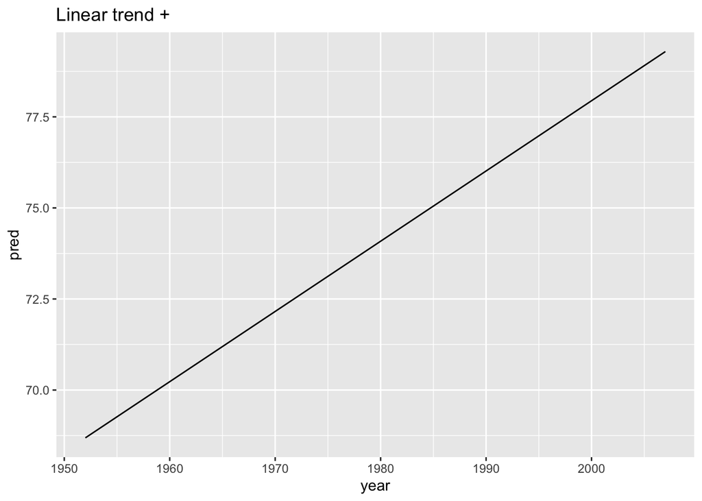

`r nz %>% add_residuals(nz_mod) %>% ggplot(aes(year, resid)) + geom_hline(yintercept = 0, colour = "white", size = 3) + geom_line() + ggtitle("Remaining pattern")`

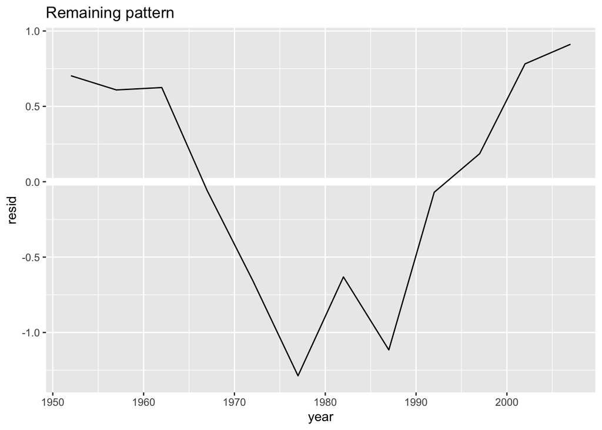

how to easily fit that model to every country?

## 25.2.1 Nested data

extract out common code with a function and repeat using map function from purrr - to repeat an action for each country (a subset of rows), need a nested data frame

```r by_country <- gapminder %>% group_by(country, continent) %>% nest()

by_country ```

`` ## # A tibble: 142 x 3 ## # Groups: country, continent [142] ## country continent data ## <fct> <fct> <list> ## 1 Afghanistan Asia <tibble [12 × 4]> ## 2 Albania Europe <tibble [12 × 4]> ## 3 Algeria Africa <tibble [12 × 4]> ## 4 Angola Africa <tibble [12 × 4]> ## 5 Argentina Americas <tibble [12 × 4]> ## 6 Australia Oceania <tibble [12 × 4]> ## 7 Austria Europe <tibble [12 × 4]> ## 8 Bahrain Asia <tibble [12 × 4]> ## 9 Bangladesh Asia <tibble [12 × 4]> ## 10 Belgium Europe <tibble [12 × 4]> ## # … with 132 more rows ## # ℹ Use `print(n = ...)` to see more rows ``

this creates data frame with one row per group (per country) with unusual column data! data is a list of data frames (tibbles to be precise)

`r # pluck out single entry in data to look at it by_country$data[[1]]`

`## # A tibble: 12 x 4 ## year lifeExp pop gdpPercap ## <int> <dbl> <int> <dbl> ## 1 1952 28.8 8425333 779. ## 2 1957 30.3 9240934 821. ## 3 1962 32.0 10267083 853. ## 4 1967 34.0 11537966 836. ## 5 1972 36.1 13079460 740. ## 6 1977 38.4 14880372 786. ## 7 1982 39.9 12881816 978. ## 8 1987 40.8 13867957 852. ## 9 1992 41.7 16317921 649. ## 10 1997 41.8 22227415 635. ## 11 2002 42.1 25268405 727. ## 12 2007 43.8 31889923 975.`

## 25.2.2 List-columns

now that have nested data frame, in good position to fit some models

```r country_model <- function(df) { lm(lifeExp ~ year, data = df) }

# and want to apply it to every data frame. apply country_model to each element models <- map(by_country$data, country_model) ```

better to store list of models as column in by_country data frame - storing related objects in columns key value of data frames - instead of creating new object in global env, create new variable in by_country - a job for mutate()!

`r by_country <- by_country %>% mutate(model = map(data, country_model)) by_country`

`` ## # A tibble: 142 x 4 ## # Groups: country, continent [142] ## country continent data model ## <fct> <fct> <list> <list> ## 1 Afghanistan Asia <tibble [12 × 4]> <lm> ## 2 Albania Europe <tibble [12 × 4]> <lm> ## 3 Algeria Africa <tibble [12 × 4]> <lm> ## 4 Angola Africa <tibble [12 × 4]> <lm> ## 5 Argentina Americas <tibble [12 × 4]> <lm> ## 6 Australia Oceania <tibble [12 × 4]> <lm> ## 7 Austria Europe <tibble [12 × 4]> <lm> ## 8 Bahrain Asia <tibble [12 × 4]> <lm> ## 9 Bangladesh Asia <tibble [12 × 4]> <lm> ## 10 Belgium Europe <tibble [12 × 4]> <lm> ## # … with 132 more rows ## # ℹ Use `print(n = ...)` to see more rows ``

makes it easier to sort and filter

`r by_country %>% filter(continent == "Europe")`

`` ## # A tibble: 30 x 4 ## # Groups: country, continent [30] ## country continent data model ## <fct> <fct> <list> <list> ## 1 Albania Europe <tibble [12 × 4]> <lm> ## 2 Austria Europe <tibble [12 × 4]> <lm> ## 3 Belgium Europe <tibble [12 × 4]> <lm> ## 4 Bosnia and Herzegovina Europe <tibble [12 × 4]> <lm> ## 5 Bulgaria Europe <tibble [12 × 4]> <lm> ## 6 Croatia Europe <tibble [12 × 4]> <lm> ## 7 Czech Republic Europe <tibble [12 × 4]> <lm> ## 8 Denmark Europe <tibble [12 × 4]> <lm> ## 9 Finland Europe <tibble [12 × 4]> <lm> ## 10 France Europe <tibble [12 × 4]> <lm> ## # … with 20 more rows ## # ℹ Use `print(n = ...)` to see more rows ``

## 25.2.3 Unnesting

now have 142 dataframes and 142 models, to compute residuals call add_residuals() with each model-data pair

`r by_country <- by_country %>% mutate( resids = map2(data, model, add_residuals) ) by_country`

`` ## # A tibble: 142 x 5 ## # Groups: country, continent [142] ## country continent data model resids ## <fct> <fct> <list> <list> <list> ## 1 Afghanistan Asia <tibble [12 × 4]> <lm> <tibble [12 × 5]> ## 2 Albania Europe <tibble [12 × 4]> <lm> <tibble [12 × 5]> ## 3 Algeria Africa <tibble [12 × 4]> <lm> <tibble [12 × 5]> ## 4 Angola Africa <tibble [12 × 4]> <lm> <tibble [12 × 5]> ## 5 Argentina Americas <tibble [12 × 4]> <lm> <tibble [12 × 5]> ## 6 Australia Oceania <tibble [12 × 4]> <lm> <tibble [12 × 5]> ## 7 Austria Europe <tibble [12 × 4]> <lm> <tibble [12 × 5]> ## 8 Bahrain Asia <tibble [12 × 4]> <lm> <tibble [12 × 5]> ## 9 Bangladesh Asia <tibble [12 × 4]> <lm> <tibble [12 × 5]> ## 10 Belgium Europe <tibble [12 × 4]> <lm> <tibble [12 × 5]> ## # … with 132 more rows ## # ℹ Use `print(n = ...)` to see more rows ``

`r # turn list of data frames back into regular data frame, use unnest() resids <- unnest(by_country, resids) resids`

`` ## # A tibble: 1,704 x 9 ## # Groups: country, continent [142] ## country continent data model year lifeExp pop gdpPer…¹ resid ## <fct> <fct> <list> <list> <int> <dbl> <int> <dbl> <dbl> ## 1 Afghanistan Asia <tibble> <lm> 1952 28.8 8425333 779. -1.11 ## 2 Afghanistan Asia <tibble> <lm> 1957 30.3 9240934 821. -0.952 ## 3 Afghanistan Asia <tibble> <lm> 1962 32.0 10267083 853. -0.664 ## 4 Afghanistan Asia <tibble> <lm> 1967 34.0 11537966 836. -0.0172 ## 5 Afghanistan Asia <tibble> <lm> 1972 36.1 13079460 740. 0.674 ## 6 Afghanistan Asia <tibble> <lm> 1977 38.4 14880372 786. 1.65 ## 7 Afghanistan Asia <tibble> <lm> 1982 39.9 12881816 978. 1.69 ## 8 Afghanistan Asia <tibble> <lm> 1987 40.8 13867957 852. 1.28 ## 9 Afghanistan Asia <tibble> <lm> 1992 41.7 16317921 649. 0.754 ## 10 Afghanistan Asia <tibble> <lm> 1997 41.8 22227415 635. -0.534 ## # … with 1,694 more rows, and abbreviated variable name ¹gdpPercap ## # ℹ Use `print(n = ...)` to see more rows ``

now have a regular data frame, and can plot residuals

`r resids %>% ggplot(aes(year, resid)) + geom_line(aes(group = country)) + geom_smooth()`

`` ## `geom_smooth()` using method = 'gam' and formula 'y ~ s(x, bs = "cs")' ``

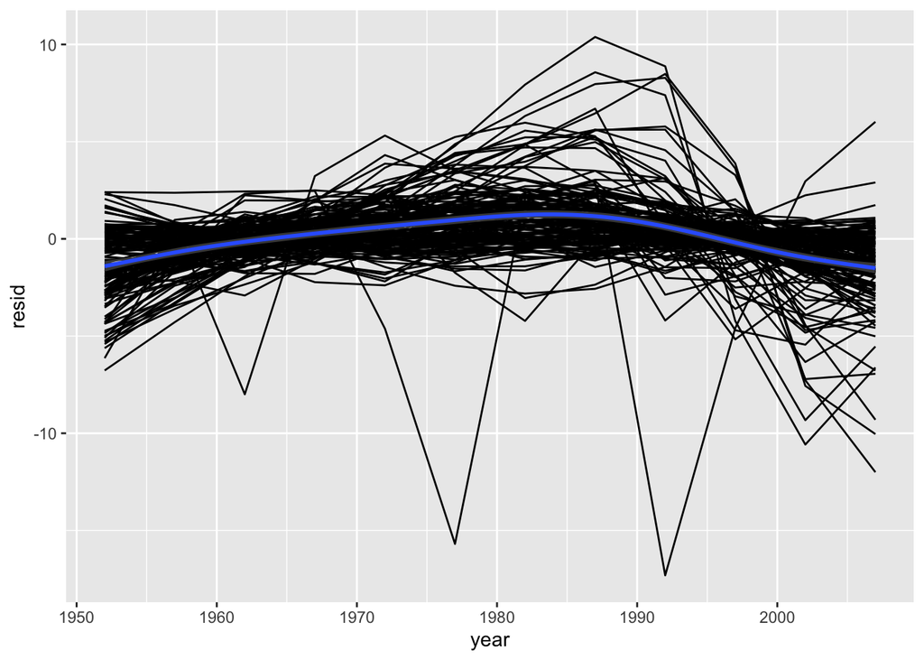

`r # can facet by continent resids %>% ggplot(aes(year, resid)) + geom_line(aes(group = country)) + geom_smooth() + facet_wrap(~continent)`

`` ## `geom_smooth()` using method = 'loess' and formula 'y ~ x' ``

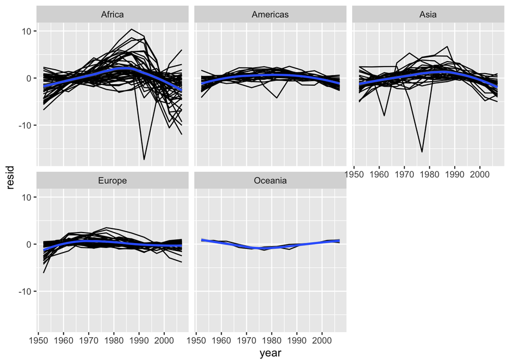

`r # lots of residuals in Africa, Asia, rest of world looks pretty good`

## 25.2.4 Model quality

Instead of looking at residuals from model, could look at some general measures of model quality

`r library(broom)`

`## ## Attaching package: 'broom'`

`## The following object is masked from 'package:modelr': ## ## bootstrap`

`r glance(nz_mod)`

`` ## # A tibble: 1 x 12 ## r.squ…¹ adj.r…² sigma stati…³ p.value df logLik AIC BIC devia…⁴ df.re…⁵ ## <dbl> <dbl> <dbl> <dbl> <dbl> <dbl> <dbl> <dbl> <dbl> <dbl> <int> ## 1 0.954 0.949 0.804 205. 5.41e-8 1 -13.3 32.6 34.1 6.47 10 ## # … with 1 more variable: nobs <int>, and abbreviated variable names ## # ¹r.squared, ²adj.r.squared, ³statistic, ⁴deviance, ⁵df.residual ## # ℹ Use `colnames()` to see all variable names ``

`r # use mutate and unnest to create data frame with row with glance for each country by_country %>% mutate(glance = map(model, glance)) %>% unnest(glance)`

`` ## # A tibble: 142 x 17 ## # Groups: country, continent [142] ## country continent data model resids r.squa…¹ adj.r…² sigma stati…³ ## <fct> <fct> <list> <list> <list> <dbl> <dbl> <dbl> <dbl> ## 1 Afghanistan Asia <tibble> <lm> <tibble> 0.948 0.942 1.22 181. ## 2 Albania Europe <tibble> <lm> <tibble> 0.911 0.902 1.98 102. ## 3 Algeria Africa <tibble> <lm> <tibble> 0.985 0.984 1.32 662. ## 4 Angola Africa <tibble> <lm> <tibble> 0.888 0.877 1.41 79.1 ## 5 Argentina Americas <tibble> <lm> <tibble> 0.996 0.995 0.292 2246. ## 6 Australia Oceania <tibble> <lm> <tibble> 0.980 0.978 0.621 481. ## 7 Austria Europe <tibble> <lm> <tibble> 0.992 0.991 0.407 1261. ## 8 Bahrain Asia <tibble> <lm> <tibble> 0.967 0.963 1.64 291. ## 9 Bangladesh Asia <tibble> <lm> <tibble> 0.989 0.988 0.977 930. ## 10 Belgium Europe <tibble> <lm> <tibble> 0.995 0.994 0.293 1822. ## # … with 132 more rows, 8 more variables: p.value <dbl>, df <dbl>, ## # logLik <dbl>, AIC <dbl>, BIC <dbl>, deviance <dbl>, df.residual <int>, ## # nobs <int>, and abbreviated variable names ¹r.squared, ²adj.r.squared, ## # ³statistic ## # ℹ Use `print(n = ...)` to see more rows, and `colnames()` to see all variable names ``

`r # don't want all the list columns glance <- by_country %>% mutate(glance = map(model, broom::glance)) %>% unnest(glance, .drop = TRUE)`

`` ## Warning: The `.drop` argument of `unnest()` is deprecated as of tidyr 1.0.0. ## All list-columns are now preserved. ``

`r glance`

`` ## # A tibble: 142 x 17 ## # Groups: country, continent [142] ## country continent data model resids r.squa…¹ adj.r…² sigma stati…³ ## <fct> <fct> <list> <list> <list> <dbl> <dbl> <dbl> <dbl> ## 1 Afghanistan Asia <tibble> <lm> <tibble> 0.948 0.942 1.22 181. ## 2 Albania Europe <tibble> <lm> <tibble> 0.911 0.902 1.98 102. ## 3 Algeria Africa <tibble> <lm> <tibble> 0.985 0.984 1.32 662. ## 4 Angola Africa <tibble> <lm> <tibble> 0.888 0.877 1.41 79.1 ## 5 Argentina Americas <tibble> <lm> <tibble> 0.996 0.995 0.292 2246. ## 6 Australia Oceania <tibble> <lm> <tibble> 0.980 0.978 0.621 481. ## 7 Austria Europe <tibble> <lm> <tibble> 0.992 0.991 0.407 1261. ## 8 Bahrain Asia <tibble> <lm> <tibble> 0.967 0.963 1.64 291. ## 9 Bangladesh Asia <tibble> <lm> <tibble> 0.989 0.988 0.977 930. ## 10 Belgium Europe <tibble> <lm> <tibble> 0.995 0.994 0.293 1822. ## # … with 132 more rows, 8 more variables: p.value <dbl>, df <dbl>, ## # logLik <dbl>, AIC <dbl>, BIC <dbl>, deviance <dbl>, df.residual <int>, ## # nobs <int>, and abbreviated variable names ¹r.squared, ²adj.r.squared, ## # ³statistic ## # ℹ Use `print(n = ...)` to see more rows, and `colnames()` to see all variable names ``

`r # look for models that don't fit well glance %>% arrange(r.squared)`

`` ## # A tibble: 142 x 17 ## # Groups: country, continent [142] ## country conti…¹ data model resids r.squ…² adj.r.…³ sigma stati…⁴ ## <fct> <fct> <list> <lis> <list> <dbl> <dbl> <dbl> <dbl> ## 1 Rwanda Africa <tibble> <lm> <tibble> 0.0172 -0.0811 6.56 0.175 ## 2 Botswana Africa <tibble> <lm> <tibble> 0.0340 -0.0626 6.11 0.352 ## 3 Zimbabwe Africa <tibble> <lm> <tibble> 0.0562 -0.0381 7.21 0.596 ## 4 Zambia Africa <tibble> <lm> <tibble> 0.0598 -0.0342 4.53 0.636 ## 5 Swaziland Africa <tibble> <lm> <tibble> 0.0682 -0.0250 6.64 0.732 ## 6 Lesotho Africa <tibble> <lm> <tibble> 0.0849 -0.00666 5.93 0.927 ## 7 Cote d'Ivoire Africa <tibble> <lm> <tibble> 0.283 0.212 3.93 3.95 ## 8 South Africa Africa <tibble> <lm> <tibble> 0.312 0.244 4.74 4.54 ## 9 Uganda Africa <tibble> <lm> <tibble> 0.342 0.276 3.19 5.20 ## 10 Congo, Dem. R… Africa <tibble> <lm> <tibble> 0.348 0.283 2.43 5.34 ## # … with 132 more rows, 8 more variables: p.value <dbl>, df <dbl>, ## # logLik <dbl>, AIC <dbl>, BIC <dbl>, deviance <dbl>, df.residual <int>, ## # nobs <int>, and abbreviated variable names ¹continent, ²r.squared, ## # ³adj.r.squared, ⁴statistic ## # ℹ Use `print(n = ...)` to see more rows, and `colnames()` to see all variable names ``

`r # worst models appear to be in Africa, check with plot glance %>% ggplot(aes(continent, r.squared)) + geom_jitter(width = 0.5)`

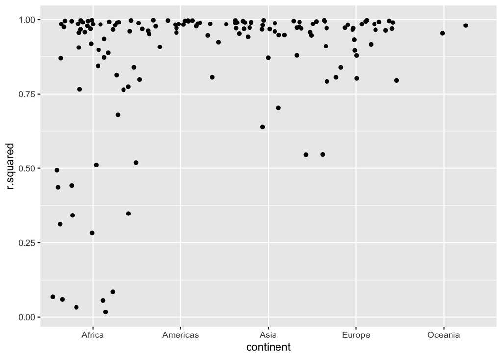

pull out countries with particularly bad R2 and plot data

```r bad_fit <- filter(glance, r.squared < 0.25)

gapminder %>% semi_join(bad_fit, by = “country”) %>% ggplot(aes(year, lifeExp, colour = country)) + geom_line() ```

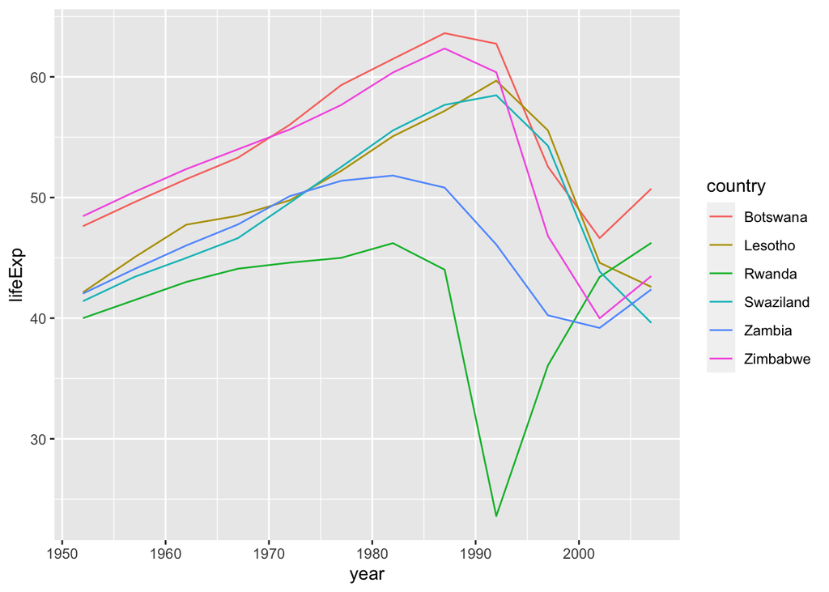

`r # see two main effects - Rwandan genocide, HIV/AIDS epidemic`

## 25.2.5 Exercises

1. A linear trend seems to be slightly too simple for the overall trend. Can you do better with a quadratic polynomial? How can you interpret the coefficients of the quadratic? (Hint you might want to transform year so that it has mean zero.) *from answers*

`r lifeExp ~ poly(year, 2)`

`## lifeExp ~ poly(year, 2)`

```r country_model <- function(df) { lm(lifeExp ~ poly(year - median(year), 2), data = df) }

by_country <- gapminder %>% group_by(country, continent) %>% nest()

by_country <- by_country %>% mutate(model = map(data, country_model))

by_country <- by_country %>% mutate( resids = map2(data, model, add_residuals) ) by_country ```

`` ## # A tibble: 142 x 5 ## # Groups: country, continent [142] ## country continent data model resids ## <fct> <fct> <list> <list> <list> ## 1 Afghanistan Asia <tibble [12 × 4]> <lm> <tibble [12 × 5]> ## 2 Albania Europe <tibble [12 × 4]> <lm> <tibble [12 × 5]> ## 3 Algeria Africa <tibble [12 × 4]> <lm> <tibble [12 × 5]> ## 4 Angola Africa <tibble [12 × 4]> <lm> <tibble [12 × 5]> ## 5 Argentina Americas <tibble [12 × 4]> <lm> <tibble [12 × 5]> ## 6 Australia Oceania <tibble [12 × 4]> <lm> <tibble [12 × 5]> ## 7 Austria Europe <tibble [12 × 4]> <lm> <tibble [12 × 5]> ## 8 Bahrain Asia <tibble [12 × 4]> <lm> <tibble [12 × 5]> ## 9 Bangladesh Asia <tibble [12 × 4]> <lm> <tibble [12 × 5]> ## 10 Belgium Europe <tibble [12 × 4]> <lm> <tibble [12 × 5]> ## # … with 132 more rows ## # ℹ Use `print(n = ...)` to see more rows ``

`r unnest(by_country, resids) %>% ggplot(aes(year, resid)) + geom_line(aes(group = country), alpha = 1 / 3) + geom_smooth(se = FALSE)`

`` ## `geom_smooth()` using method = 'gam' and formula 'y ~ s(x, bs = "cs")' ``

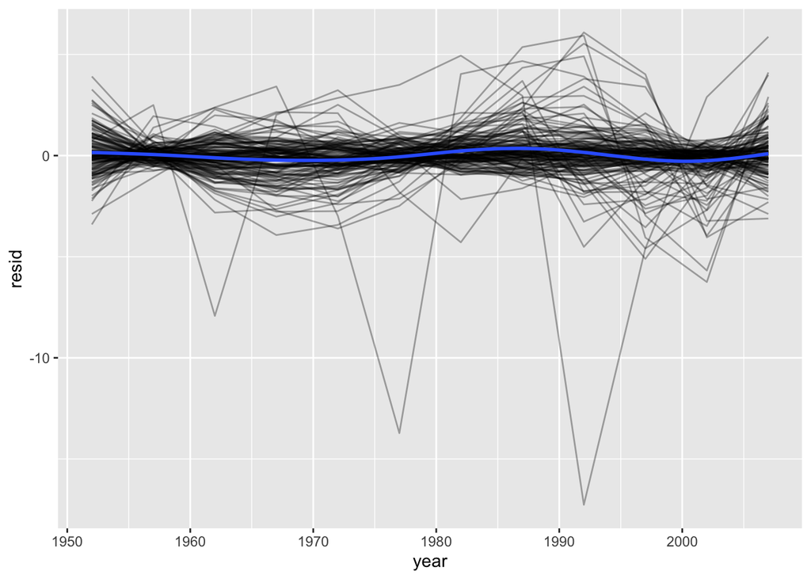

`r by_country %>% mutate(glance = map(model, broom::glance)) %>% unnest(glance, .drop = TRUE) %>% ggplot(aes(continent, r.squared)) + geom_jitter(width = 0.5)`

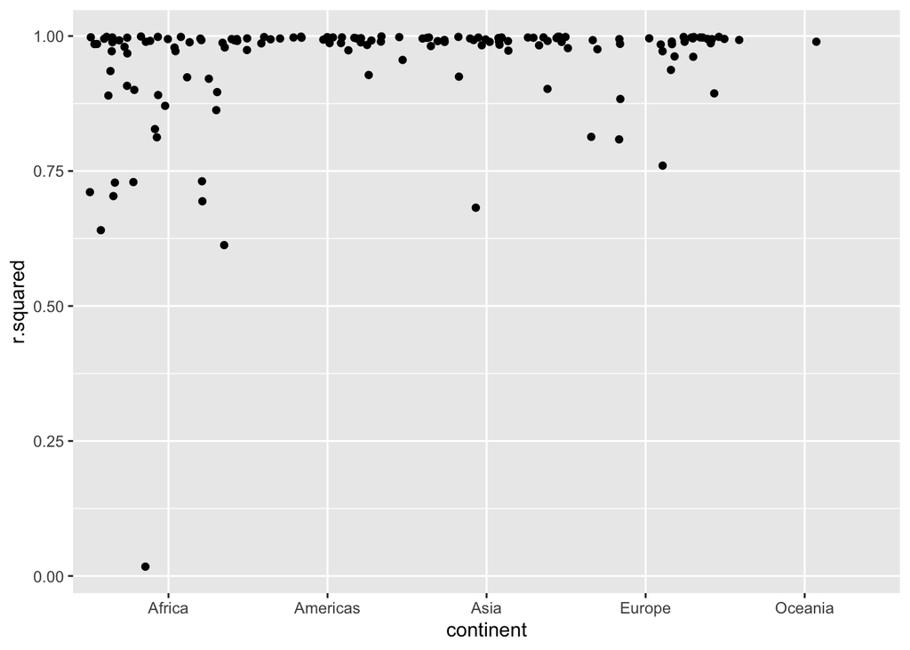

2. Explore other methods for visualising the distribution of R2 per continent. You might want to try the ggbeeswarm package, which provides similar methods for avoiding overlaps as jitter, but uses deterministic methods. *from answers*

```r library(“ggbeeswarm”)

by_country %>% mutate(glance = map(model, broom::glance)) %>% unnest(glance, .drop = TRUE) %>% ggplot(aes(continent, r.squared)) + geom_beeswarm() ```

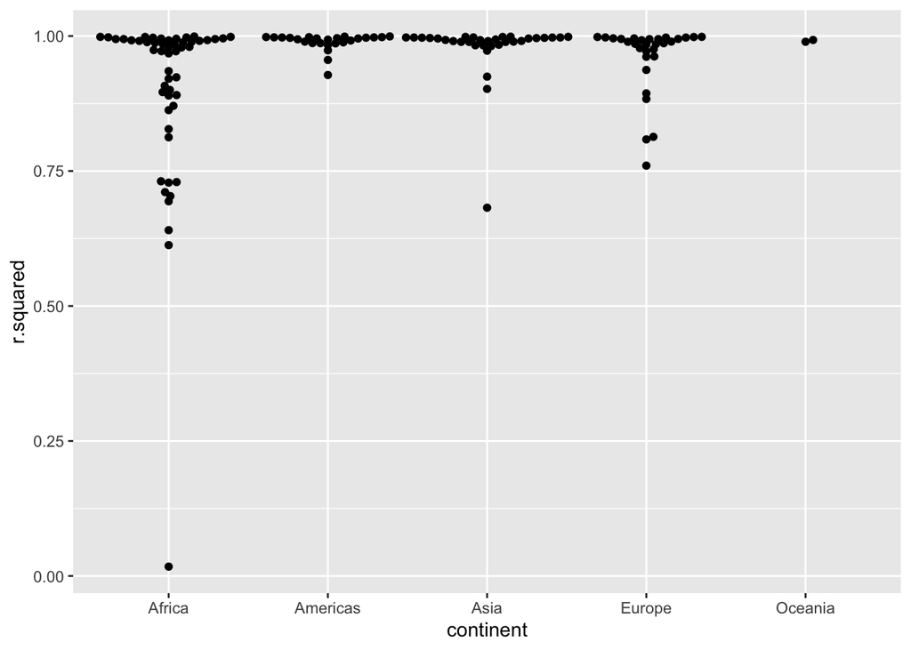

3. To create the last plot (showing the data for the countries with the worst model fits), we needed two steps: we created a data frame with one row per country and then semi-joined it to the original dataset. It’s possible to avoid this join if we use unnest() instead of unnest(.drop = TRUE). How? *from answers*

`r gapminder %>% group_by(country, continent) %>% nest() %>% mutate(model = map(data, ~lm(lifeExp ~ year, .))) %>% mutate(glance = map(model, broom::glance)) %>% unnest(glance) %>% unnest(data) %>% filter(r.squared < 0.25) %>% ggplot(aes(year, lifeExp)) + geom_line(aes(color = country))`

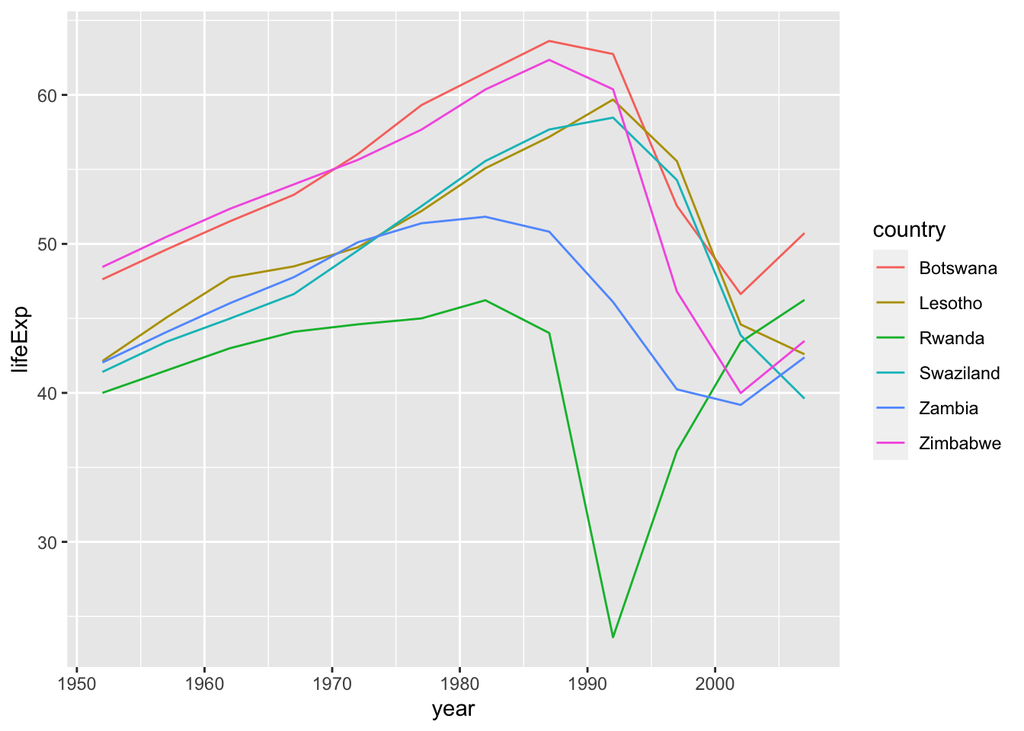

# 25.3 List-columns

dive back into some of the details for managing many models, after seeing workflow

```r
# base R doesn't make it easy to create list-columns
data.frame(x = list(1:3, 3:5))
```

```
##   x.1.3 x.3.5
## 1     1     3
## 2     2     4
## 3     3     5
```

```r
# can prevent data.frame from doing this with I(), but result doesn't print well
data.frame(
  x = I(list(1:3, 3:5)),
  y = c("1, 2", "3, 4, 5")
)
```

```
##         x       y
## 1 1, 2, 3    1, 2
## 2 3, 4, 5 3, 4, 5
```

tibble() is better

```r
tibble(
  x = list(1:3, 3:5),
  y = c("1, 2", "3, 4, 5")
)
```

```
## # A tibble: 2 x 2
##   x         y
##   <list>    <chr>
## 1 <int [3]> 1, 2
## 2 <int [3]> 3, 4, 5
```

```r
# also easier with tribble(), automatically knows that need a list:
tribble(
   ~x, ~y,
  1:3, "1, 2",
  3:5, "3, 4, 5"
)
```

```
## # A tibble: 2 x 2
##   x         y
##   <list>    <chr>
## 1 <int [3]> 1, 2
## 2 <int [3]> 3, 4, 5
```

effective list-column pipeline: - create list-column using one of nest(), summarise() + list(), or mutate() + a map function - create other intermediate list-columns by transforming existing list columns with map(), map2(), or pmap() - simplify list-column back down to data frame or atomic vector

[output not shown]

# 25.6 Making tidy data with broom

broom package provides three general tools for turning models into tidy data frames - glance(model) - returns a row for each model. each column gives a model summary, either a measure of model quality, or complexity, or both - tidy(model) - returns row for each coefficient in the model. each column gives information about estimate or variability - augment(model, data) - returns a row for each row in data, adding extra values like residuals, influence statistics